# SDS Report

Genevieve Korst

November 17, 2015

```
## magrittr    dplyr reshape2  ggplot2    RCurl
##     TRUE     TRUE     TRUE     TRUE     TRUE
```

To collect this data, I observed Welch hall from 8:45 AM – 9:00 AM on Monday, and recorded the gender and ethnicity of each student that walked by, and whether or not they were listening to music. Then, from 10:45 – 11:00 AM, I observed Burdine hall, recording the same data. From 2:45 PM – 3:00 PM I observed RLM. On Tuesday I observed the GDC from 9:15 AM – 9:30 AM, then I observed Painter from 12:15 PM – 12:30 PM, finishing with the CLA from 3:15 PM – 3:30 PM. Wednesday, I observed the west mall from 8:45 AM – 9:00 AM, and then McCombs from 10:45 AM – 11:00 AM, finishing with the main mall from 12:45 PM – 1:00 PM. On Thursday, I observed the east mall from 9:15 AM -9:30 AM, the first floor of Jester from 12:15 PM – 12:30 PM, and the UTC from 1:45 PM – 2:00 PM.

I repeated this process three times, and observed these places on different days each new process.

```r
url <- getURL("https://docs.google.com/spreadsheets/d/1Nwdb7NYm7uU6JtT_cbDf8gM1AImay-y55Z8VCKlxVFU/pub?gid=1089481875&single=true&output=csv")

data.sheet <- read.csv(textConnection(url)) %>%
  select(Location, Race, Sex, Yes, No)

# qplot(data=Sheet, x=Yes, y=No, color=Location)
# qplot(data=Sheet, x=Race, y=Yes-No, fill=Sex, geom="boxplot")
```

## Response Variable

#### Statistics

Our *Response Variable* can be measured as a difference between the number listening to music (`Yes`) and not listening to music (`No`). To create this response variable, I subtracted the following two vectors:

```r
data.sheet$Response <- data.sheet$Yes - data.sheet$No
```

Running a `five number summary` on this response vector, we get the following result:

```r
fivenum(data.sheet$Response)
```

```
## [1] -10.0  -6.0  -3.0  -1.5   2.0
```

Furthermore, we can infer from the standard deviation (SD = 3.08) that our data appears to have a wide spread. To further investigate, let’s plot a histogram of the data to check for normality

#### Plots

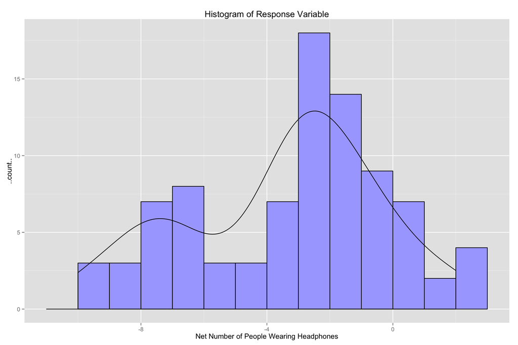

```r
suppressPackageStartupMessages(require(ggplot2))

data.sheet$Response <- as.numeric(data.sheet$Response)


ggplot(data.sheet, aes(x=Response)) +
  # geom_histogram(aes(x=Yes), alpha=0.25, color="black", fill="green", binwidth=1) +
  # geom_histogram(aes(x=No), alpha=0.25, color="black", fill="red", binwidth=1) +
  geom_histogram(alpha=1, color="black", fill="#AAAAFF", binwidth=1) +
  geom_density(fill=NA) + aes(y = ..count..) +
  labs(x="Net Number of People Wearing Headphones",
       title="Histogram of Response Variable")
```

A few inferences may be gathered from this these statistics/visualization.

The first inference is that we might have a binomial distribution (there is a peak at -3 and a smaller peak at -7). It’s possible that a disproportionate sample size of white students (and an under representation of black students) could be skewing the data.

However, if we disregard the possibility of a binomial distribution, our data looks to be normally distributed (without any obvious outliers).

## Explanitory Variables

In this experiment, I attempted to explain the response variable on the basis of two *Explanatory Variables*: Sex and Race/Ethnicity.

#### Sex: Histogram

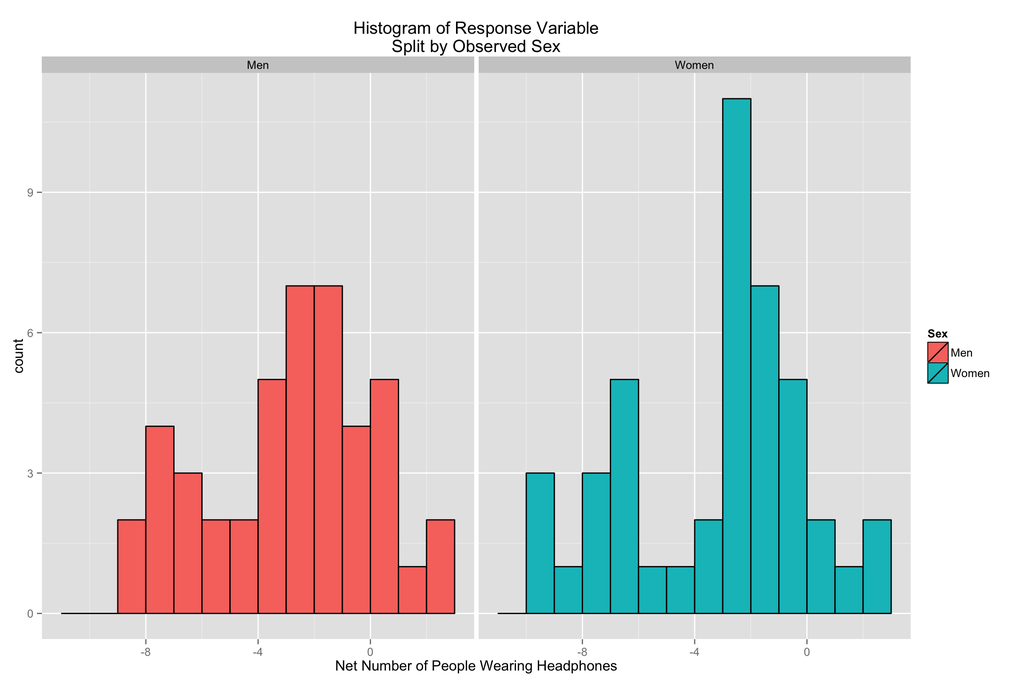

```r
group_by(data.sheet, Sex) %>%
  ggplot(aes(x=Response, fill=Sex)) +
  geom_histogram(alpha=1, color="black", binwidth=1) +
  facet_wrap("Sex") +
  labs(x="Net Number of People Wearing Headphones",
       title="Histogram of Response Variable\nSplit by Observed Sex")
```

Based on initial impressions from the histogram above, it appears that wearing headphones isn’t clearly influenced by sex.

#### Sex: Density

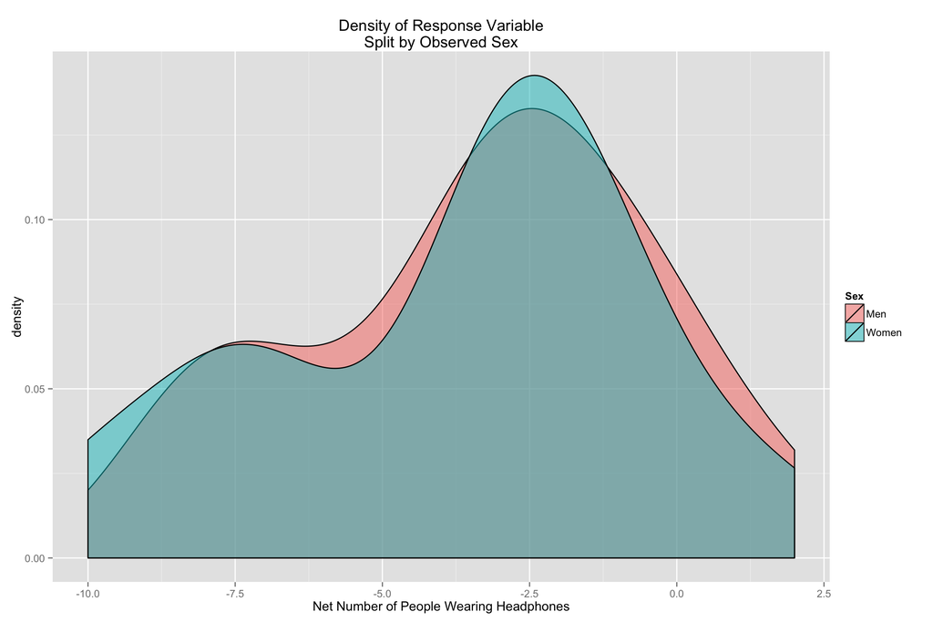

```r
group_by(data.sheet, Sex) %>%
  ggplot(aes(x=Response, fill=Sex)) +
  geom_density(alpha=0.5, color="black") +
  # facet_wrap("Sex") +
  labs(x="Net Number of People Wearing Headphones",
       title="Density of Response Variable\nSplit by Observed Sex")
```

This density plot represents that same distribution as the histogram above, but gives the edges a more smooth appearance. This plot strongly suggests that sex alone is not a good predictor of an individual’s preference to wear headphones.

Sex: Statistics

```r
# Sum the 'Yes' & 'No' vectors to get our total sample size
data.sheet$Total.Responses <- data.sheet$Yes + data.sheet$No

# Make two new fata.frames, broken down by sex
Male   <- filter(data.sheet, Sex=="Men") %>% select(-Sex)
Female <- filter(data.sheet, Sex=="Women") %>% select(-Sex)
```

```r
fivenum(Male$Response)
## [1] -9.0 -5.5 -3.0 -1.0  2.0
sd(Male$Response)
## [1] 2.9723
```

```r
fivenum(Female$Response)
## [1] -10  -7  -3  -2   2
sd(Female$Response)
## [1] 3.20148
```

Again, it appears that there isn’t a significant distinction between females and males. These broad statistics support my initial inferences based on the plots

#### Race/Ethnicity: Histogram

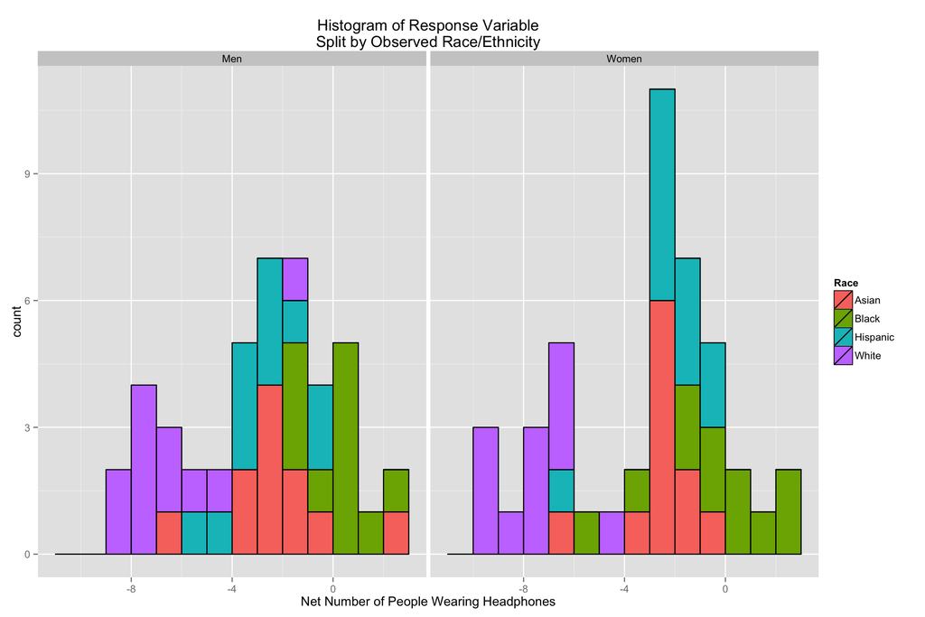

```r
group_by(data.sheet, Race) %>%
  ggplot(aes(x=Response, fill=Race)) +
  geom_histogram(alpha=1, color="black", binwidth=1) +
  facet_wrap("Sex") +
  labs(x="Net Number of People Wearing Headphones",
       title="Histogram of Response Variable\nSplit by Observed Race/Ethnicity")
```

#### Race/Ethnicity: Density

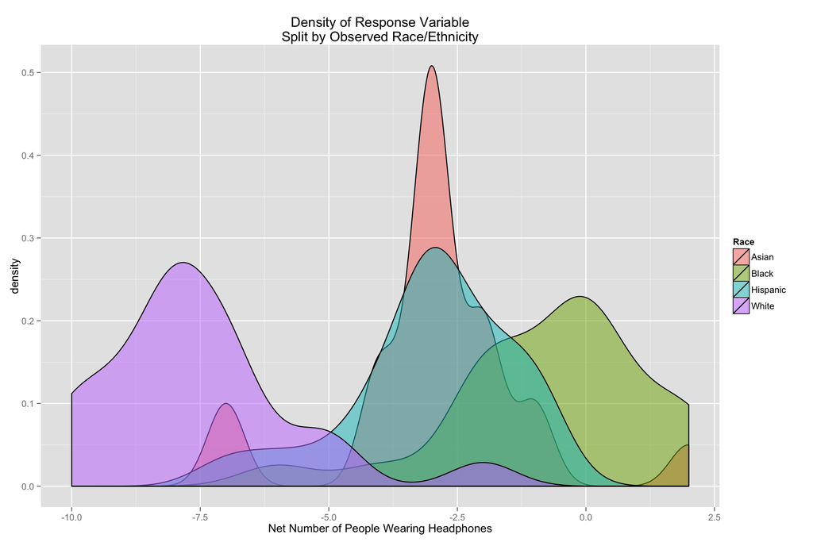

```r
group_by(data.sheet, Race) %>%
  ggplot(aes(x=Response, fill=Race)) +
  geom_density(alpha=0.5, color="black") +
  # facet_wrap("Sex") +
  labs(x="Net Number of People Wearing Headphones",
       title="Density of Response Variable\nSplit by Observed Race/Ethnicity")
```

#### Race/Ethnicity: Statistics

```r
White <- filter(data.sheet, Race=="White") %>% select(-Race)
Hispanic <- filter(data.sheet, Race=="Hispanic") %>% select(-Race)
Asian <- filter(data.sheet, Race=="Asian") %>% select(-Race)
Black <- filter(data.sheet, Race=="Black")  %>% select(-Race)
```

```r
fivenum(White$Response)
## [1] -10  -9  -8  -7  -2
sd(White$Response)
## [1] 1.87025
```

```r
fivenum(Hispanic$Response)
## [1] -7 -4 -3 -2 -1
sd(Hispanic$Response)
## [1] 1.573592
```

```r
fivenum(Asian$Response)
## [1] -7 -3 -3 -2  2
sd(Asian$Response)
## [1] 1.849301
```

```r
fivenum(Black$Response)
## [1] -6 -2  0  0  2
sd(Black$Response)
## [1] 1.936771
```

These stats seem to suppourt my inference from the graphs, praticualry the variation between whites and blacks.